Meta-analysis of clinical and preclinical studies comparing the anticancer

efﬁcacy of liposomal versus conventional

non-liposomal doxorubicin<sup>☆</sup><sup>,</sup><sup>☆☆</sup>

Grant H. Petersen, Saeed K. Alzghari <sup>1</sup>, Wayne Chee <sup>2</sup>, Sana S. Sankari, Ninh M. La-Beck ⁎

Department of Immunotherapeutics and Biotechnology, Texas Tech University Health Sciences Center School of Pharmacy, Abilene, TX, USA

a b s t r a c t

a r t i c l e

i n f o

Article history:

Received 11 February 2016

Received in revised form 12 April 2016

Accepted 18 April 2016

Available online 22 April 2016

While liposome-mediated delivery of cytotoxic chemotherapy has been shown to signiﬁcantly enhance drug tol-

erability in patients as compared to the conventional formulation, the fundamental question remains whether

they also improve anticancer efﬁcacy. Thus, we performed a systematic literature search for randomized clinical

trials directly comparing efﬁcacy of liposomal cytotoxic chemotherapy versus their equivalent conventional for-

mulation. The search yielded 14 clinical trials (8 anthracycline, 4 cisplatin, 1 paclitaxel, 1 irinotecan) that meet

inclusion criteria, with a total of 2589 patients. We found that efﬁcacy in patients was not different between lipo-

somal and conventional chemotherapy as assessed by objective response (odds ratio 1.03; 95% conﬁdence inter-

val [CI] 0.82–1.30), overall survival (hazard ratio [HR] 1.05; 95% CI 0.95–1.17), and progression free survival rates

(HR 1.01; 95% CI, 0.92–1.11). Subgroup analyses of only the anthracycline trials also did not show any efﬁcacy

advantage for the liposomal formulation. Since pegylated liposomal doxorubicin (PLD) was the most prevalent

formulation in these clinical trials, we also performed a meta-analysis of 11 preclinical studies comparing efﬁcacy

of PLD and conventional doxorubicin in tumor-bearing mice. In contrast with clinical results, animal studies

showed signiﬁcantly increased survival in mice treated with PLD compared to conventional doxorubicin (HR

0.39; 95% CI 0.27–0.56). We discuss the possible reasons why the pharmacological advantages of carrier-

mediated chemotherapy did not translate into enhanced clinical efﬁcacy including the role of the enhanced per-

meability and retention (EPR) effect and the tumor microenvironment, the optimal dosing regimen for carrier-

mediated agents, and the lack of standardization in the conduct and reporting of preclinical studies evaluating

anticancer efﬁcacy of these agents. Our study shows that the full clinical potential of carrier-mediated drugs re-

mains to be realized and highlights some of the critical knowledge gaps that must be addressed in order to move

the ﬁeld forward.

© 2016 Elsevier B.V. All rights reserved.

Keywords:

Doxorubicin

Cisplatin

Daunorubicin

Liposome

Nanomedicine

Nanoparticle

1. Introduction

Targeted drug delivery to tumor tissue remains one of the major

challenges in the treatment of cancer and systemically administered

therapies continue to have severe dose limiting toxicities. Nanoparticle

carriers, typically between 10 and 200 nm in size, have tremendous

therapeutic potential in the treatment of cancer because they can in-

crease tumor drug delivery while limiting normal tissue distribution

and can protect the drug from degradation [1–3]. Theoretically, this

would increase anticancer efﬁcacy and decrease systemic toxicity.

Pegylated liposomal doxorubicin (PLD; Doxil/Caelyx) is regarded as

the ﬁrst approved anticancer nanoparticle and has been shown to im-

prove patient tolerability as compared to conventional chemotherapy

[4,5]. A major limitation of conventional doxorubicin is cumulative

dose-related cardiac toxicity. However cardiac toxicity was not ob-

served with the nanoparticle formulation, PLD, until signiﬁcantly higher

lifetime doses are reached [6–8]. This enhanced tolerability and tumor

drug delivery should result in increased anticancer efﬁcacy. However,

clinical trials have not demonstrated clear evidence of superior efﬁcacy

of PLD over conventional doxorubicin. Over the last two decades, nu-

merous different anticancer nanoparticles have been developed and in-

vestigated in hundreds of preclinical and clinical studies. Yet, only a

handful has met efﬁcacy criteria for regulatory approval, and the major-

ity of these utilize liposomal platforms (Table 1).

The fundamental question remains whether liposomal formulations

of cytotoxic chemotherapies signiﬁcantly improve anticancer efﬁcacy

Journal of Controlled Release 232 (2016) 255–264

☆ Funding source: none.

☆☆ Disclosure: The authors declare that there is no conﬂict of interest regarding the pub-

lication of this paper.

⁎ Corresponding author at: Department of Immunotherapeutics and Biotechnology,

Texas Tech University Health Sciences Center School of Pharmacy, 1718 Pine St, Abilene,

TX 79601, USA.

E-mail address: irene.la-beck@ttuhsc.edu (N.M. La-Beck).

1 Present address: Department of Pharmacy, Scott & White Memorial Hospital, Baylor

Scott & White Health, Temple, TX, USA.

2 Present address: Midland Memorial Hospital, Midland, TX, USA.

[figure not shown]

http://dx.doi.org/10.1016/j.jconrel.2016.04.028

0168-3659/© 2016 Elsevier B.V. All rights reserved.

[figure not shown]

Contents lists available at ScienceDirect

Journal of Controlled Release

journal homepage: www.elsevier.com/locate/jconrel

over conventional non-liposomal formulations. Hence, we per-

formed a meta-analysis of clinical trials comparing the anticancer ef-

ﬁcacy of liposomal cytotoxic chemotherapy to their conventional

non-liposomal formulations. Moreover, given the low success rates

of carrier-mediated drugs in cancer clinical trials, there is an urgent

need to understand deﬁciencies in the current preclinical drug de-

velopment strategies in order to develop new approaches that are

more predictive of clinical results. Since PLD is the most extensively

studied liposomal drug, we also performed a meta-analysis of pre-

clinical studies comparing the anticancer efﬁcacy of PLD and conven-

tional doxorubicin in murine tumor models.

2. Methods

2.1. Literature search

A systematic literature search was conducted in PubMed, Scopus, ISI,

and Google Scholar for studies published between 1990 and 2015, using

the terms “liposom* AND free”, and “liposom* AND conventional”. The

article type was ﬁltered to include only clinical trials; no other ﬁlters

were applied. The full search is available upon request. All the studies

and any potentially relevant articles found in their reference lists were

reviewed and considered for inclusion.

To identify preclinical studies evaluating liposomal doxorubicin, a

systematic literature search was performed similar to methods de-

scribed above with the following modiﬁcations. The search terms used

in the databases were “doxorubicin”, “liposomes”, “animals”, “neo-

plasms OR drug therapy”, and “murine”. No ﬁlters were used. As with

the clinical literature search, any potentially relevant articles found in

reference lists were reviewed and considered for inclusion.

2.2. Inclusion and exclusion criteria

The criteria for inclusion in the meta-analysis of the efﬁcacy of lipo-

somal versus conventional formulations were: randomized trial, con-

tains both a cohort treated with the liposomal formulation and cohort

treated with the equivalent conventional formulation, and evaluation

of efﬁcacy endpoints (response rate, overall survival, or progression-

free survival). All cancer types, pretreatment status, and concurrent

treatments were allowed. Studies were excluded if the regimens in

the treatment arms differed by more than just liposomal or convention-

al formulation, efﬁcacy results were not reported, treatment allocation

was not randomized, or if the coefﬁcient of variation for data estimated

by three independent investigators was N15%.

For the meta-analysis of preclinical studies evaluating liposomal

doxorubicin, studies were included if they contained both PLD and con-

ventional doxorubicin treatment cohorts, evaluated anticancer efﬁcacy

in at least one tumor model, and published the survival curves. For stud-

ies that compared PLD and conventional doxorubicin in more than one

tumor model, the survival curve for each tumor model was included.

Studies were excluded if the regimens in the treatment arms differed

by more than just liposomal or conventional formulation, survival

curves were not reported, or if the coefﬁcient of variation for data esti-

mated by three independent investigators was N15%.

2.3. Data extraction

Extraction of study characteristics and efﬁcacy data from text, tables,

and ﬁgures of included studies was done independently by three inves-

tigators. Differences were resolved by consensus. For the clinical trials,

study characteristics (ﬁrst author, journal, year of publication), trial de-

sign characteristics (study design, outcome measurement, type of can-

cer, therapy regimen for each arm), study population (median age,

number of patients evaluated for efﬁcacy endpoints in each arm), and

efﬁcacy results (hazard ratios [HR] and 95% conﬁdence intervals [CI]

for survival data, and objective response rates [ORR]) were recorded.

For the preclinical studies, study characteristics (ﬁrst author, journal,

year of publication) and study design characteristics (mouse model,

tumor model, number of mice in each cohort, therapy regimen for

each cohort, endpoints) were recorded. For all preclinical studies, and

for clinical trials in which the HR or a CI for survival data were not pro-

vided, three investigators independently analyzed the Kaplan-Meier

curves to estimate these data using the method described by Parmar

et al. [16]. The coefﬁcient of variation of the data estimated indepen-

dently by the investigators ranged from 0.85% to 9.86% for the clinical

trials and b0.01% to 14.18% for the preclinical studies included in the

analyses. The mean of the three independent estimates was used for

the meta-analyses. Two preclinical studies were excluded due to a coef-

ﬁcient of variation N15% for their estimated HR, and one preclinical

study was excluded due to a 95% CI approaching zero on one side and

inﬁnity on the other, indicating a high degree of uncertainty in the esti-

mated HR.

2.4. Statistical analyses

For survival variables such as OS and PFS, the HR and the corre-

sponding 95% CI were used in the meta-analysis with results presented

as forest plots. For response rates, the crude OR and the corresponding

95% CI was used in the meta-analysis with results presented as forest

plots. Heterogeneity was assessed by Cochran's Q test and I<sup>2</sup>index. A

random-effects model (DerSimonian and Laird method) was used for

the meta-analysis if the results of the heterogeneity test was Q N k-1,

where k is the number of studies, and P b 0.1, otherwise a ﬁxed-effect

model was used (Mantel-Haenszel method) [17,18]. An overall analysis

of all clinical trials and an overall analysis of all preclinical studies were

conducted. Subgroup analyses were also carried out as detailed in the

subsequent sections. All meta-analyses were performed using MIX 2.0

software (BiostatXL), with a two-tailed P-value of b0.05 considered as

statistically signiﬁcant. Funnel plots with Egger's test were used to de-

tect publication bias [19]. An Egger's regression intercept with a

P b 0.1 was considered signiﬁcant for publication bias.

2.5. Assessment of clinical trial quality and design bias

The clinical trial quality and potential design bias were evaluated

using the criteria described in the Cochrane handbook for systematic

reviews of interventions [20]. These parameters included details of se-

quence generation, allocation concealment, treatment blinding, com-

pleteness of outcomes data, presence of selective outcome reporting,

and analysis by intent to treat.

Table 1

Anticancer nanoparticles approved for clinical use.

Trade name

Carrier

Drug cargo

Size

Approved indications

Doxil/Caelyx [9]

PEGylated liposome

Doxorubicin

90 nm

AIDS-related Kaposi sarcoma, multiple myeloma, ovarian cancer

Myocet [10]

Liposome

Doxorubicin

150 nm

Metastatic breast cancer

DaunoXome [11]

Liposome

Daunorubicin

45 nm

AIDS-related Kaposi sarcoma

Marqibo [12]

Liposome

Vincristine

100 nm

Acute lymphoblastic leukemia

Onivyde [13]

PEGylated liposome

Irinotecan

110 nm

Pancreatic adenocarcinoma

DepoCyt [14]

Liposome

Cytarabine

3–30 μm [15]

Lymphomatous meningitis

256

G.H. Petersen et al. / Journal of Controlled Release 232 (2016) 255–264

3. Results

3.1. Search results

The search for clinical trials yielded 270 publications, of which 14

met criteria for inclusion in the meta-analysis as summarized in

Fig. 1. Of these 14 studies, 8 compared liposomal and conventional

anthracycline formulations, 4 compared liposomal and conventional

cisplatin formulations, and 1 each compared liposomal and conven-

tional formulations of irinotecan and paclitaxel, respectively. These

studies included a total of 2589 patients randomized 1:1 to either li-

posomal or conventional formulations of chemotherapy who were

evaluated for the efﬁcacy endpoints. The characteristics of these

studies, including treatment regimens and patient population, are

further summarized in Table 2.

For the preclinical studies, the search yielded 224 publications, of

which 10 articles containing 11 studies met the criteria for inclusion

in the meta-analysis, as summarized in Fig. 2. These studies included a

total of 143 mice treated with PLD and 137 mice treated with conven-

tional doxorubicin. The characteristics of these studies, including treat-

ment regimens and tumor models, are summarized in Table 3.

3.2. Meta-analyses

Objective response rates were evaluated in all fourteen trials, and OS

and PFS were evaluated in twelve of the fourteen trials. Meta-analysis

showed no signiﬁcant difference between liposomal vs. conventional

formulations in objective response rates (OR, 1.03; 95% CI, 0.82–1.30;

p = 0.77) (Fig. 3), OS (HR, 1.05; 95% CI, 0.95–1.17; p = 0.34) (Fig. 4),

or PFS (HR, 1.01; 95% CI, 0.92–1.11; p = 0.86) (Fig. 5). Subgroup analysis

of the eight anthracycline trials also showed no signiﬁcant difference

between liposomal vs. conventional formulations in objective response

rates (OR, 0.94; 95% CI, 0.78–1.14; p = 0.54), OS (HR, 1.01; 95% CI, 0.89–

1.15; p = 0.84), and PFS (HR, 1.06; 95% CI, 0.95–1.18; p = 0.30). In con-

trast, subgroup analysis of the four platinum trials showed a signiﬁcant

improvement in objective response rates for liposomal cisplatin com-

pared to conventional cisplatin (OR, 1.49; 95% CI, 1.06–2.09; p =

0.02). Subgroup analysis of OS and PFS endpoints were not performed

for the cisplatin trials since only 2 of the trials reported these endpoints.

in response rate may be related to the drug cargo (i.e., cisplatin) or

may be related to the cancer type (i.e., lung cancer). Given that the

tumor type speciﬁc parameters such as vascularity can impact the phar-

macokinetics and pharmacodynamics of liposomal drugs, we also per-

formed a subgroup analysis of only the metastatic breast cancer trials

(n = 3) which also did not show any improvements in efﬁcacy with

the liposomal anthracyclines as compared to conventional formulations

(Supplemental Table S1). There were insufﬁcient numbers of trials for

subgroup analyses of the other cancer types. Since pegylated and non-

pegylated liposomes may have different pharmacokinetic parameters,

we performed separate subgroup analyses for pegylated liposomal

anthracyclines (n = 5) and non-pegylated liposomal anthracyclines

(n = 3) which also failed to show any efﬁcacy advantages for either of

the liposomal formulations (Supplemental Table S1). No evidence of

publication bias was detected (Supplemental Fig. S1A-C).

In contrast to the results of the clinical studies, the overall survival

rate in mice treated with PLD was signiﬁcantly higher than in those

treated with conventional doxorubicin, HR 0.39 (95% CI 0.27–0.56;

p b 0.0001) (Fig. 6). The efﬁcacy advantage of the liposomal formulation

persists in subgroup analyses of immunocompetent mouse models

mental Fig. S1D).

3.3. Clinical trial quality and risk of bias

The potential for study design bias is summarized in Table 4. Al-

though all the clinical trials allocated patients to treatment arms ran-

domly, most did not report how the sequences were generated and

whether this was concealed during the trial period. Eight of the fourteen

trials were open-label, 5 were conducted with evaluators blinded to

treatment assignment, and 1 trial did not publish information on

blinding. Intent to treat analysis was reported in 11 of the 14 trials,

and only 2 trials showed evidence of incomplete outcomes data. Togeth-

er, these trial characteristics suggest a moderate risk of study design

bias, particularly due to the lack of treatment concealment.

4. Discussion

Our meta-analyses found that the superior antitumor efﬁcacy of li-

posomal doxorubicin over conventional doxorubicin in preclinical stud-

ies generally did not translate to the clinical trial setting. Although these

ﬁndings are somewhat expected based on the cumulative reports pub-

lished in the cancer drug delivery ﬁeld [41], our study is the ﬁrst to sys-

tematically and objectively quantify these effects. The purported

advantages of liposomal formulations include longer circulation and en-

hanced drug delivery to tumor tissue, however, these factors did not

lead to enhanced anticancer efﬁcacy in patients. There are many possi-

ble explanations for this including the challenges associated with

conducting clinical trials and limitations of preclinical tumor models

(Fig. 7), and they have been previously reviewed in detail [41]. In our

study, most of the patients included in the analyses had advanced or

metastatic cancer, were often refractory to multiple treatment modali-

ties, and their malignant diseases typically have arisen and evolved

over months and years. In contrast, the murine tumor models in our

analyses were predominantly implantable tumors that grow rapidly

and reach endpoint within a period of weeks. This rapid growth is

often accompanied by high rates of neoangiogenesis which can exag-

gerate the enhanced permeability and retention (EPR) effect and

hence amplify passive tumor targeting by carrier-mediated drugs [42].

Another explanation for the absence of clinical efﬁcacy advantage

with the liposomal formulation could be that the dosing regimen may

be optimized for the non-liposomal formulation rather than the liposo-

mal formulation. Given the complex and markedly different pharmaco-

kinetics of carrier-mediated drugs as compared to the non-carrier

mediated drug [43], it is probable that the optimal regimen for the

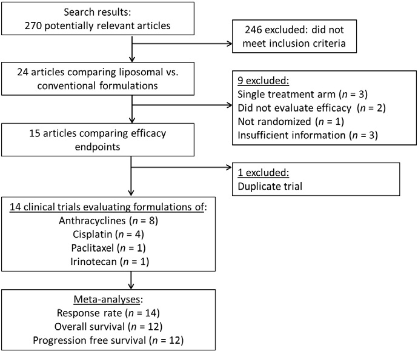

Fig. 1. Flow diagram of the systematic literature search for clinical trials comparing

anticancer efﬁcacy of a liposomal formulation of chemotherapy to its conventional non-

carrier mediated formulation.

257

G.H. Petersen et al. / Journal of Controlled Release 232 (2016) 255–264

liposomal formulation will be different than the conventional formula-

tion. The available evidence with liposomal doxorubicin would suggest

that there are dose and cycle dependent pharmacokinetic changes that

need to be taken into consideration [44] and that larger single doses

may be more efﬁcacious than smaller split doses [35]. However, the

ideal administration schedule for liposomal drugs remains to be thor-

oughly evaluated in patients.

One intriguing explanation for the lack of a clinical efﬁcacy advan-

tage for the liposomal formulation could be the tumor immunologic mi-

lieu. The tumor microenvironment has been reported to be inﬁltrated

with immunosuppressive leukocytes such as M2-polarized tumor-

associated macrophages (TAMs), myeloid-derived suppressor cells

(MDSC), and regulatory T cells that are believed to be key players in

the progression of cancer [45–47]. Although nanoparticles are known

to be internalized by splenic and hepatic phagocytes, and circulating

monocyte numbers and function have been shown to correlate with

nanoparticle clearance in patients [48,49], the interactions between

nanoparticles and TAMs is relatively unexplored. Recent studies have

found that non-drug loaded nanoparticles, including liposomes similar

to the PLD carrier, enhanced tumor growth compared to vehicle control

in tumor-bearing immunocompetent mice [50,51]. This was associated

with polarization of TAMs toward an M2-like phenotype, suppression of

antitumor T cell responses, and enhanced tumor angiogenesis in the li-

posome treated animals [50]. Given this evidence, it is possible that

something similar occurs in patients treated with liposomes, such that

the beneﬁts of improved drug delivery to tumors are offset by a shift

of immune cells toward the tumor-promoting phenotype (Fig. 8).

This effect of the carrier would likely not be detected in our meta-

analysis since 5 of the 11 preclinical studies used immunodeﬁcient

athymic nude (Nu/nu) mice which lack functional T cells. Moreover,

even “wild-type” mouse strains such as DBA/2 can have subtle but ob-

servable immune defects due to inbreeding. The DBA/2 mouse strain

used in two of the analyzed studies is known to have a loss-of-

function mutation in complement component 5 (C5) [52]. Importantly,

Table 2

Characteristics of included clinical studies.

Study (year)

Treatment arms

Number of

patients

Median Age

(years)

Concurrent

treatments

Type of

trial

Cancer type

Judson et al. [21]

PLD 50 mg/m<sup>2</sup>every 28 days

50

52

None

phase II

Soft tissue sarcoma

Doxorubicin 75 mg/m<sup>2</sup>every 21 days

44

52

Dimopoulos et al. [22]

PLD 40 mg/m<sup>2</sup>every 28 days

132

66

Vincristine Dexamethasone

phase III

Multiple myeloma

Doxorubicin 9 mg/m<sup>2</sup>every 28 days

127

65

O'Brien et al. [6]

PLD 50 mg/m<sup>2</sup>every 28 days

254

58

None

phase III

Metastatic breast cancer

Doxorubicin 60 mg/m<sup>2</sup>every 21 days

255

57

Rifkin et al. [23]

PLD 40 mg/m<sup>2</sup>every 28 days

97

60

Vincristine Dexamethasone

phase III

Multiple myeloma

Doxorubicin 9 mg/m<sup>2</sup>every 28 days

95

60

Hunault-Berger et al.

[24]

PLD 40 mg/m<sup>2</sup>days 1–4

31

68

Vincristine Dexamethasone

phase II

Philadelphia chromosome-negative

acute lymphoblastic leukemia

Doxorubicin 12 mg/m<sup>2</sup>/day days 1–4

29

66

Batist et al. [4]

Liposomal doxorubicin 60 mg/m<sup>2</sup>every

21 days

142

55

Cyclophosphamide

phase III

Metastatic breast cancer

Doxorubicin 60 mg/m<sup>2</sup>every 21 days

155

54

Harris et al. [25]

Liposomal doxorubicin 75 mg/m<sup>2</sup>every

21 days

108

58

None

phase III

Metastatic breast cancer

Doxorubicin 75 mg/m<sup>2</sup>every 21 days

116

58

Latagliata et al. [26]

Daunoxome 80 mg/m<sup>2</sup>days 1–3

148

68

Cytarabine All-trans retinoic

acid

phase III

Acute myelogenous leukemia

Daunorubicin 45 mg/m<sup>2</sup>days 1–3

153

68

Jehn et al. [27]

Liposomal cisplatin 100 mg/m<sup>2</sup>every 21

days

25

56

None

phase III

Squamous cell carcinoma of the

head and neck

Cisplatin 100 mg/m<sup>2</sup>every 21 days

21

58

Kosmas et al. [28]

Liposomal cisplatin 120 mg/m<sup>2</sup>every 21

days

60

NS

Gemcitabine

phase III

NSCLC

Cisplatin 100 mg/m2 every 21 days

41

NS

Mylonakis et al. [29]

Liposomal cisplatin 120 mg/m<sup>2</sup>every 21

days

47

64

Gemcitabine

phase II

NSCLC

Cisplatin 100 mg/m<sup>2</sup>every 21 days

41

66

Stathopoulos et al.

[30]

Liposomal cisplatin 200 mg/m<sup>2</sup>every 14

days

114

65

Paclitaxel

phase III

Non-squamous NSCLC

Cisplatin 75 mg/m<sup>2</sup>every 14 days

115

66

Yang et al. [31]

Liposomal paclitaxel 150 mg/m<sup>2</sup>every 21

days

50

53

Cisplatin

NS

NSCLC

Paclitaxel 150 mg/m<sup>2</sup>every 21 days

50

55

Roy et al. [32]

Liposomal irinotecan 120 mg/m2 every

21 days

44

56

None

phase II

gastric or gastro-esophageal

adenocarcinoma

Irinotecan 300 mg/m2 every 21 days

44

62

PLD, pegylated liposomal doxorubicin; NSCLC, non-small cell lung cancer; NS, not speciﬁed.

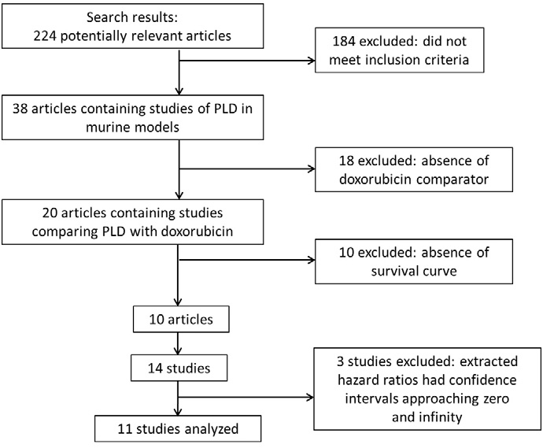

Fig. 2. Flow diagram of the systematic literature search for preclinical studies comparing

the anticancer efﬁcacy of liposomal doxorubicin to conventional doxorubicin in mouse

models of cancer.

258

G.H. Petersen et al. / Journal of Controlled Release 232 (2016) 255–264

Table 3

Characteristics of included preclinical studies.

Study ID

Tumor model (implant route)

Cancer type

Mouse

PLD (n)

Conventional doxorubicin (n)

Other cohorts (n)

[33]

MDA-MB-231-BR (intracranial)

human breast adenocarcinoma

Nu/nu

20

20

PBS (33)

ABT-888 (18)

dox + ABT-888 (36)

PLD + ABT-888 (35)

[34] (A)

M109 (i.p.)

murine lung carcinoma

BALB/c

16

15

No treatment (9)

PLD + IL-2 (16)

PLD + PEG-SUV-IL-2 (8)

PLD + MLV-IL-2 (16)

IL-2 (9)

MLV-IL-2 (9)

[34] (B)

M109 (i.v.)

murine lung carcinoma

BALB/c

16

16

No treatment (16)

PLD + IL-2 (8)

PLD + PEG-SUV-IL-2 (15)

PLD + MLV-IL-2 (8)

IL-2 (8)

PEG-SUV-IL-2 (8)

[35]

C26 (s.c.)

murine colon carcinoma

BALB/c

11<sup>⁎</sup>

10

No treatment (10)

[36]

C26 (s.c.)

murine colon carcinoma

BALB/c

28

24

Saline (23)

Non-PEG L-Dox (29)

[37]

L1210JF (i.p.)

murine leukemia

DBA/2

8

8

Saline (8)

Folate-coated PLD (8)

[38]

HTLA-230 (i.v.)

human neuroblastoma

Nu/nu

8<sup>⁎</sup>

8

HEPES buffer (8)

Free-aGD2 Fab’ (8)

Fab’-SIL (8)

Fab’-SIL + dox (8)

[39] (A)

GI-LI-N (adrenal gland)

human neuroblastoma

Nu/nu

10

10

HBSS (10)

TVT-dox (10)

[39] (B)

Colo-699 N (intrapulmonary)

human lung carcinoma

Nu/nu

10

10

HBSS (10)

TVT-dox (10)

[39] (C)

OVCAR-3 (i.p.)

human ovarian adenocarcinoma

Nu/nu

10

10

HBSS (10)

TVT-dox (10)

[40]

L1210 (s.c.)

murine leukemia

DBA/2

6

6

Cationic L-Dox (6)

Neutral L-Dox (6)

Empty cationic liposomes (6)

PLD; pegylated liposomal doxorubicin; i.p., intraperitoneal; i.v., intravenous; s.c., subcutaneous; PBS, phosphate buffered saline; ABT-888, A poly-ADP-ribose polymerase (PARP) inhibitor;

dox; doxorubicin; PEG-SUV-IL-2, pegylated liposomal interleukin-2; MLV-IL-2, liposomal interleukin-2; Free-aGD2 Fab’, Fab’ fragment of anti-disialoganglioside antibodies; Fab’-SIL, Fab’

fragment of anti-disialoganglioside antibodies coupled to stealth immunoliposomes; HBSS, Hank's balanced salt solution; TVT-dox, tumor vasculature-targeted liposomal doxorubicin; L-

Dox, liposomal doxorubicin.

⁎ Used the same formulations at multiple dosing schedules; only the most effective regimen of each formulation was included in the analysis.

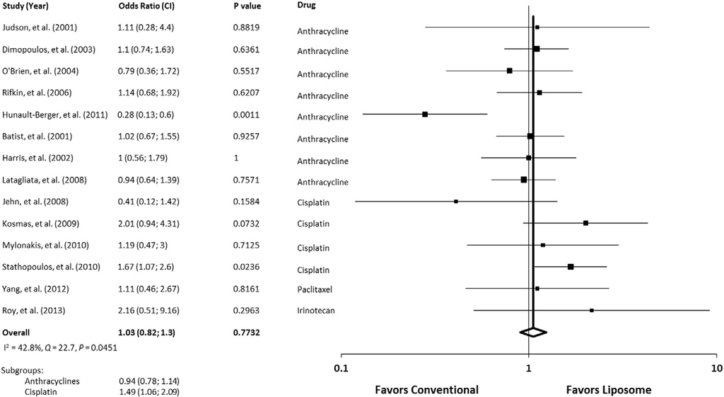

Fig. 3. Objective response in patients treated with liposomal versus conventional chemotherapy formulations.

259

G.H. Petersen et al. / Journal of Controlled Release 232 (2016) 255–264

nanoparticles are known to interact with plasma proteins, including

the complement proteins, and these interactions can alter pharma-

cokinetic parameters such as clearance of the delivery system [53].

Moreover, in mice treated with polymer nanoparticles, enhanced

tumor growth has been linked to increased production of the

anaphylatoxin C5a from C5 cleavage [51]. This phenomenon would

not be discernable using DBA/2 and other C5 deﬁcient “wild-type”

mouse strains. Interestingly, only one study in our meta-analysis

reported results from a placebo liposome control cohort and, al-

though liposomes and other nanoparticles are known to have nu-

merous immunological effects [54,55], none of the preclinical

studies reported performing any immune assessments.

In our initial preclinical data search, most of the studies were exclud-

ed due to the absence of a published survival curve. The principal efﬁca-

cy endpoint for these animal studies was tumor size which is in contrast

to survival endpoints which are the gold-standard measurements of

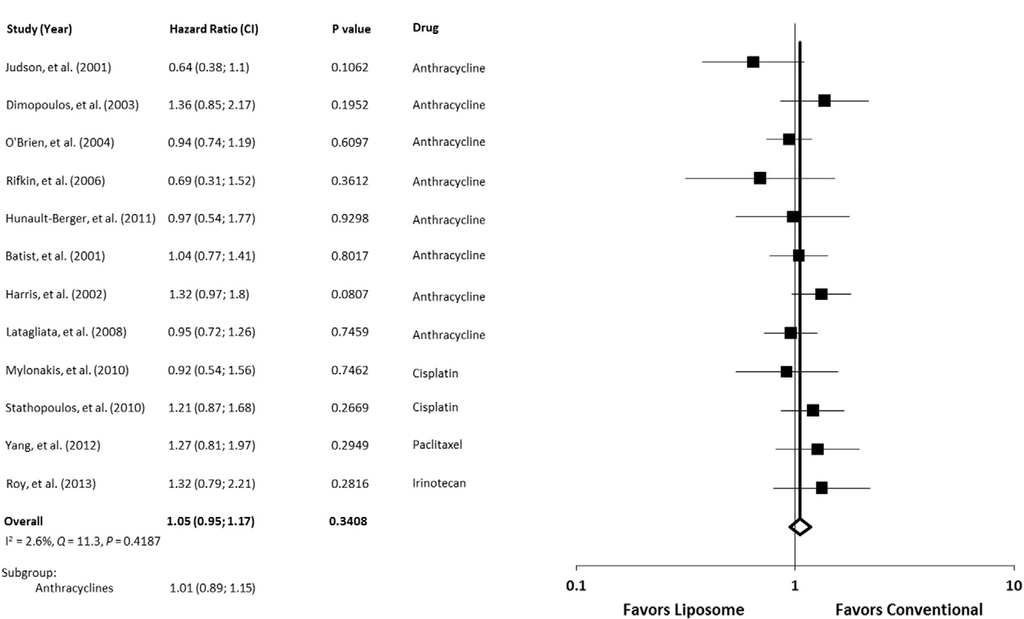

Fig. 4. Overall survival in patients treated with liposomal versus conventional chemotherapy formulations.

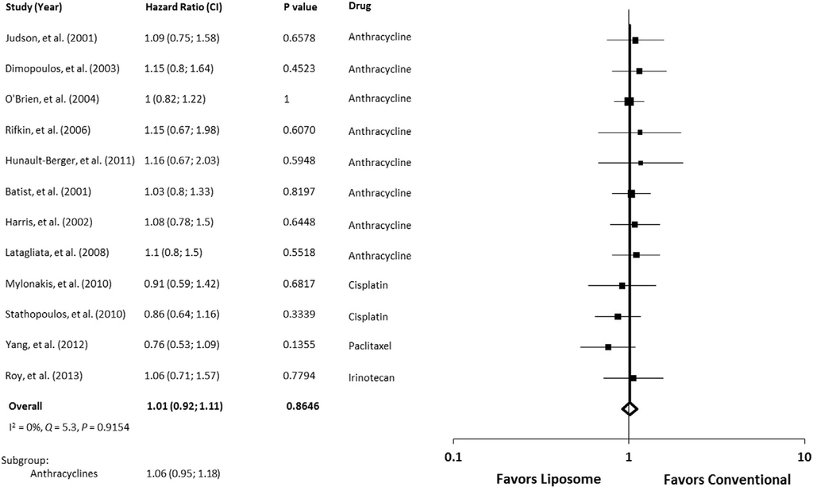

Fig. 5. Progression free survival in patients treated with liposomal versus conventional chemotherapy formulations.

260

G.H. Petersen et al. / Journal of Controlled Release 232 (2016) 255–264

efﬁcacy in clinical trials. This could be another reason for the lack of

translation of efﬁcacy from preclinical mouse models to clinical tri-

als. It has been shown in clinical trials that tumor response rates

(e.g., size shrinkage) are not accurate predictors of survival beneﬁt

[56,57]. Yet, the predominant strategy for the preclinical develop-

ment of anticancer therapies continues to rely heavily on tumor re-

sponse as a measurement of efﬁcacy. It is possible that utilization

of survival as an efﬁcacy endpoint in animal studies may be more

predictive of clinical efﬁcacy, however formal assessments of this re-

lationship are currently lacking.

To our knowledge, we are the ﬁrst to systematically compare the

preclinical and clinical survival beneﬁts of antineoplastic liposomal

drugs. These initial ﬁndings should be interpreted with caution due to

the high degree of heterogeneity between the preclinical studies in

tumor models, treatment protocols, and endpoint assessments. This

lack of standardized procedures is a major barrier to determining the

translatability of preclinical efﬁcacy endpoints and tumor models. To

facilitate the translation of preclinical ﬁndings to the clinical trial setting,

we propose that consensus guidelines be created for conducting and

reporting of results from preclinical studies evaluating nanoparticle

drug efﬁcacy. The current preclinical development framework for anti-

neoplastic agents includes xenograft tumor models to assess anticancer

efﬁcacy against human cancers. In addition, liposomal formulations can

also signiﬁcantly alter the side effect proﬁle; liposomal doxorubicin has

signiﬁcantly less cardiac toxicity than conventional doxorubicin, how-

ever there is an increased incidence of acute infusion reactions and mu-

cocutaneous toxicity. The preclinical development strategies have

adapted to these new ﬁndings by including rodent models to assess

the risk of cardiotoxicity [58], swine models to assess the risk of acute

infusion reactions [59], and canine models have been found to repro-

duce mucocutaneous toxicities similar to those seen in patients [60].

Given the recent evidence showing that carrier-immune interactions

can impact tumor growth, we would further recommend the inclusion

of immunocompetent tumor models, inclusion of control cohorts

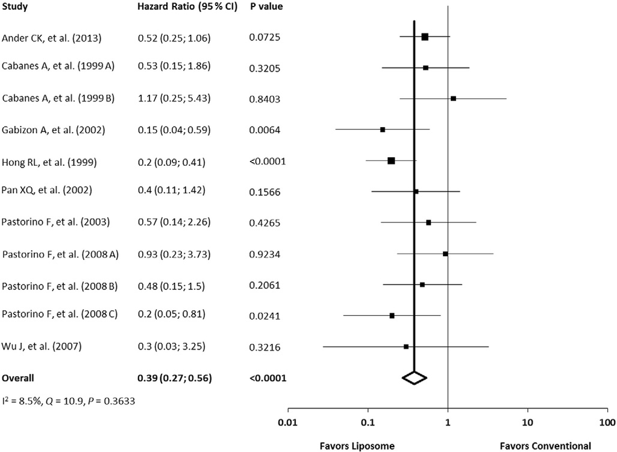

Fig. 6. Overall survival in tumor bearing mice treated with pegylated liposomal doxorubicin versus conventional doxorubicin.

Table 4

Quality assessment of the included clinical trials.

Study

Sequence generation

Allocation

concealment

Blinding

Incomplete outcome

data

Selective outcome

reporting

Intent-to-treat

analysis

Other potential

threats

Judson [21]

Random; unclear

Unclear

No

No

Yes

Yes

Yes

Dimopoulos [22]

Random; permuted blocks

Unclear

No

No

Yes

Yes

Yes

O′Brien [6]

Random; computer generator

Yes

No

No

Yes

No

Yes

Rifkin [23]

Random; unclear

Unclear

Evaluators blinded

No

Yes

Yes

Yes

Hunault-Berger [24]

Random; unclear

Unclear

No

No

Yes

Yes

Yes

Batist [4]

Random; balanced blocks

Unclear

Evaluators blinded

No

Yes

Yes

Yes

Harris [25]

Random; balanced blocks

Unclear

Evaluators blinded

No

Yes

Yes

Yes

Latagliata [26]

Random; unclear

Unclear

No

No

Yes

Yes

Yes

Jehn [27]

Random; unclear

Unclear

No

Yes

Yes

No

Yes

Kosmas [28]

Random; unclear

Unclear

Unclear

Yes

Yes

No

Yes

Mylonakis [29]

Random; unclear

Unclear

No

No

Yes

Yes

Yes

Stathopoulos [30]

Random; permuted blocks

Unclear

Evaluators blinded

No

Yes

Yes

Yes

Yang [31]

Random; unclear

Unclear

No

No

Yes

Yes

Yes

Roy [32]

Random; unclear

Unclear

Evaluators blinded

No

Yes

Yes

Yes

261

G.H. Petersen et al. / Journal of Controlled Release 232 (2016) 255–264

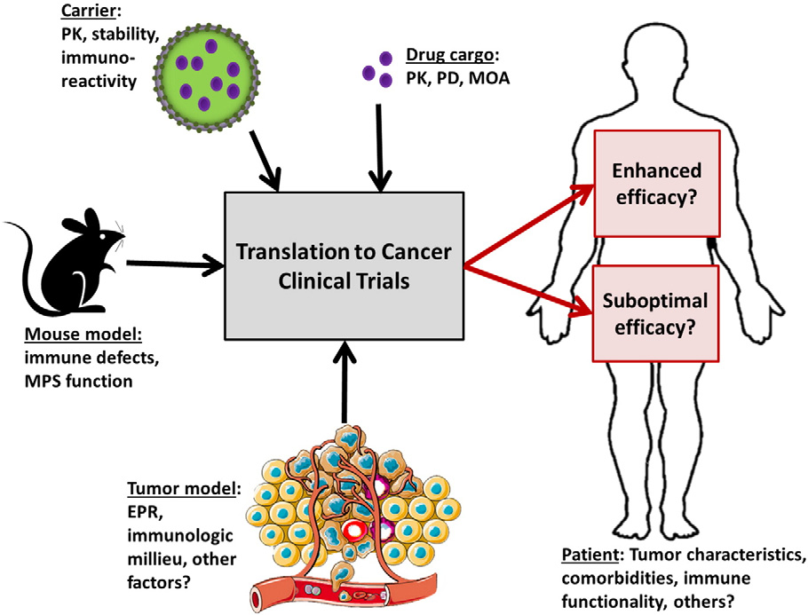

Fig. 7. Challenges associated with translating the anticancer efﬁcacy of carrier-mediated drugs from preclinical studies to clinical trials. PK, pharmacokinetics; PD, pharmacodynamics,

MOA, mechanisms of action; MPS, mononuclear phagocyte system; EPR, enhanced permeability and retention.

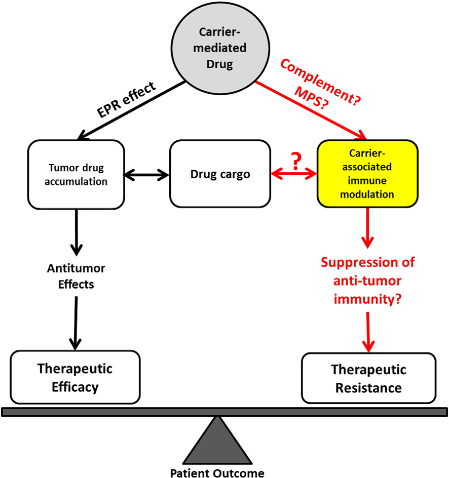

Fig. 8. A model of how interactions between liposomal drugs and the immunologic milieu may impact clinical anticancer efﬁcacy. EPR, enhanced permeability and retention; MPS,

mononuclear phagocyte system.

262

G.H. Petersen et al. / Journal of Controlled Release 232 (2016) 255–264

treated with placebo carriers, and routine in vivo assessments of im-

mune activation and inhibition. It may even be considered prudent to

include these or similar studies as prerequisites for carrier-mediated

drugs seeking to enter cancer clinical trials. In addition, survival should

be considered as an endpoint in preclinical studies and testing on indo-

lent and metastatic tumor models should be encouraged.

There are several other limitations to our study. While we found that

liposomal formulations were not more clinically efﬁcacious than their

conventional formulations in patients, the majority of the included trials

evaluated anthracyclines (doxorubicin and daunorubicin). Further sub-

group analysis of only the cisplatin trials showed that the liposomal for-

mulation had higher response rates than conventional cisplatin.

Whether this enhanced efﬁcacy is true with regards to OS and PFS re-

mains to be determined as we could not evaluate this due to the lack

of published data on these endpoints. Moreover, all the patients in the

as vascularity and immunogenicity that is associated with cancer type.

Interestingly, subgroup analysis of only metastatic breast cancer pa-

tients showed no improvement in any efﬁcacy endpoints. However,

the breast cancer subgroup also comprised only liposomal anthracycline

formulations. It is not possible in our meta-analysis to determine

whether this difference in efﬁcacy advantage between lung cancer and

breast cancer patients is due to differences in cancer biology or due to

the differences in pharmacology upon liposome-encapsulation of plati-

num versus anthracycline agents. Thus, additional prospective clinical

trials and preclinical mechanistic studies are needed to elucidate the

role of the drug cargo and the tumor microenvironment in the antican-

cer efﬁcacy of liposomal drugs.

Our study focused on liposomal formulations because they are

the most extensively utilized carrier platform in cancer patients

and subgroup analyses of simple liposomal versus pegylated liposo-

mal anthracyclines did not show an improvement in efﬁcacy over

conventional formulations with either type of liposomes. Since carri-

er physicochemical characteristics can impact their interactions with

cellular and molecular components in vivo resulting in different drug

release rates, tissue distribution, etc. [55,61,62], the results of our

meta-analysis should not be generalized to other types of carriers.

Moreover, given the complex and distinct mechanisms of action of

different cytotoxic agents, our ﬁndings should not be generalized

to other chemotherapeutic agents beyond anthracyclines and cis-

platin. Clearly, more clinical trials directly comparing carrier-

mediated and conventional chemotherapy formulations are needed.

However, it is not evident that these trials will be forthcoming. Most

of the trials in our initial search results were excluded because they

compared liposomal formulation to standard of care regimens that

did not contain the equivalent conventional formulation, and this

appears to be the predominant strategy in the clinical development

of anticancer nanoparticles.

5. Conclusions

The full clinical potential of carrier-mediated drugs remains to be re-

alized and many unanswered questions persist regarding the pharma-

cology of these agents. The optimal dosing regimen for carrier-

mediated agents has not been thoroughly investigated and it is possible

that this will differ from that of the conventional formulation. Moreover,

the contribution of the EPR effect and the tumor microenvironment to

clinical efﬁcacy needs to be fully elucidated. In particular the mecha-

nisms and consequences of their interaction with the immune system

in cancer are currently unclear. Finally, the development of consensus

guidelines on the conduct and reporting of preclinical studies evaluating

anticancer nanoparticles is needed in order to facilitate the interpreta-

tion and translation of results from animal models.

Supplementary data to this article can be found online at http://dx.

doi.org/10.1016/j.jconrel.2016.04.028.

References

[1] H. Maeda, J. Fang, T. Inutsuka, Y. Kitamoto, Vascular permeability enhancement in

solid tumor: various factors, mechanisms involved and its implications, Int.

Immunopharmacol. 3 (2003) 319–328.

[2] A. Gabizon, D. Papahadjopoulos, Liposome formulations with prolonged circulation

time in blood and enhanced uptake by tumors, Proc. Natl. Acad. Sci. U. S. A. 85

(1988) 6949–6953.

[3] T. Golan, T. Grenader, P. Ohana, et al., Pegylated liposomal mitomycin C prodrug en-

hances tolerance of mitomycin C: a phase 1 study in advanced solid tumor patients,

Cancer Med. 4 (2015) 1472–1483.

[4] G. Batist, G. Ramakrishnan, C.S. Rao, et al., Reduced cardiotoxicity and preserved an-

titumor efﬁcacy of liposome-encapsulated doxorubicin and cyclophosphamide

compared with conventional doxorubicin and cyclophosphamide in a randomized,

multicenter trial of metastatic breast cancer, J. Clin. Oncol. 19 (2001) 1444–1454.

[5] J.M. Gibson, S. Alzghari, C. Ahn, et al., The role of pegylated liposomal doxorubicin in

ovarian cancer: a meta-analysis of randomized clinical trials, Oncologist 18 (2013)

1022–1031.

[6] M.E. O'Brien, N. Wigler, M. Inbar, et al., Reduced cardiotoxicity and comparable efﬁ-

cacy in a phase III trial of pegylated liposomal doxorubicin HCl (CAELYX/Doxil) ver-

sus conventional doxorubicin for ﬁrst-line treatment of metastatic breast cancer,

Ann. Oncol. 15 (2004) 440–449.

[7] R. Soloman, A.A. Gabizon, Clinical pharmacology of liposomal anthracyclines: focus

on pegylated liposomal doxorubicin, Clin. Lymphoma Myeloma 8 (2008) 21–32.

[8] D. Uyar, B. Kulp, G. Peterson, et al., Cardiac safety proﬁle of prolonged (Nor = 6 cy-

cles) pegylated liposomal doxorubicin administration in patients with gynecologic

malignancies, Gynecol. Oncol. 94 (2004) 147–151.

[9] Doxil [Package Insert], Janssen Products, LP, Horsham, PA, 2013.

[10] Myocet [Package Insert], Teva Pharma, Netherlands, 2013.

[11] DaunoXome [Package Insert], Galen US, Inc., Souderton, PA, 2011.

[12] Marqibo [Package Insert], Talon Therapeutics, Inc., San Franscisco, CA, 2012.

[13] Onivyde [Package Insert], Merrimack Pharmaceuticals, Inc., Cambridge, MA, 2015.

[14] DepoCyt [Package Insert], ENZON Pharmaceuticals, Bridgwater, NJ, 2010.

[15] R. Swords, C. O'Rafferty, F. Giles, P. Browne, Spurious elevation of the cerebrospinous

ﬂuid white cell counts in three patients receiving liposomal cytarabine as part of

post-remission therapy, Leukemia 22 (2008) 2277–2278.

[16] M.K. Parmar, V. Torri, L. Stewart, Extracting summary statistics to perform meta-

analyses of the published literature for survival endpoints, Stat. Med. 17 (1998)

2815–2834.

[17] R. DerSimonian, N. Laird, Meta-analysis in clinical trials, Control. Clin. Trials 7 (1986)

177–188.

[18] N. Mantel, W. Haenszel, Statistical aspects of the analysis of data from retrospective

studies of disease, J. Natl. Cancer Inst. 22 (1959) 719–748.

[19] J.A. Sterne, D. Gavaghan, M. Egger, Publication and related bias in meta-analysis:

power of statistical tests and prevalence in the literature, J. Clin. Epidemiol. 53

(2000) 1119–1129.

[20] J.P. Higgins (Ed.), SG. Cochrane Handbook for Systematic Reviews of Interventions,

The Cochrane Collaboration, 2011.

[21] I. Judson, J.A. Radford, M. Harris, et al., Randomised phase II trial of pegylated liposo-

mal doxorubicin (DOXIL/CAELYX) versus doxorubicin in the treatment of advanced

or metastatic soft tissue sarcoma: a study by the EORTC Soft Tissue and Bone Sarco-

ma Group, Eur. J. Cancer 37 (2001) 870–877.

[22] M.A. Dimopoulos, A. Pouli, K. Zervas, et al., Prospective randomized comparison of

vincristine, doxorubicin and dexamethasone (VAD) administered as intravenous

bolus injection and VAD with liposomal doxorubicin as ﬁrst-line treatment in mul-

tiple myeloma, Ann. Oncol. 14 (2003) 1039–1044.

[23] R.M. Rifkin, S.A. Gregory, A. Mohrbacher, M.A. Hussein, Pegylated liposomal doxoru-

bicin, vincristine, and dexamethasone provide signiﬁcant reduction in toxicity com-

pared with doxorubicin, vincristine, and dexamethasone in patients with newly

diagnosed multiple myeloma: a phase III multicenter randomized trial, Cancer 106

(2006) 848–858.

[24] M. Hunault-Berger, T. Leguay, X. Thomas, et al., A randomized study of pegylated li-

posomal doxorubicin versus continuous-infusion doxorubicin in elderly patients

with acute lymphoblastic leukemia: the GRAALL-SA1 study, Haematologica 96

(2011) 245–252.

[25] L. Harris, G. Batist, R. Belt, et al., Liposome-encapsulated doxorubicin compared with

conventional doxorubicin in a randomized multicenter trial as ﬁrst-line therapy of

metastatic breast carcinoma, Cancer 94 (2002) 25–36.

[26] R. Latagliata, M. Breccia, P. Fazi, et al., Liposomal daunorubicin versus standard dau-

norubicin: long term follow-up of the GIMEMA GSI 103 AMLE randomized trial in

patients older than 60 years with acute myelogenous leukaemia, Br. J. Haematol.

143 (2008) 681–689.

[27] C.F. Jehn, T. Boulikas, A. Kourvetaris, et al., First safety and response results of a ran-

domized phase III study with liposomal platin in the treatment of advanced squa-

mous cell carcinoma of the head and neck (SCCHN), Anticancer Res. 28 (2008)

3961–3964.

[28] C. Kosmas, J. Angel, A. Athanasiou, et al., 9088 phase III study of lipoplatin plus

gemcitabine versus cisplatin plus gemcitabine in advanced NSCLC; interim analysis,

Eur. J. Cancer Suppl. 7 (2009) 531.

[29] N. Mylonakis, A. Athanasiou, N. Ziras, et al., Phase II study of liposomal cisplatin

(Lipoplatin) plus gemcitabine versus cisplatin plus gemcitabine as ﬁrst line treat-

ment in inoperable (stage IIIB/IV) non-small cell lung cancer, Lung Cancer 68

(2010) 240–247.

[30] G.P. Stathopoulos, D. Antoniou, J. Dimitroulis, et al., Liposomal cisplatin combined

with paclitaxel versus cisplatin and paclitaxel in non-small-cell lung cancer: a ran-

domized phase III multicenter trial, Ann. Oncol. 21 (2010) 2227–2232.

263

G.H. Petersen et al. / Journal of Controlled Release 232 (2016) 255–264

[31] X. Yang, H. Zhang, J. Nong, et al., A randomized trial of liposomal paclitaxel plus cis-

platin as ﬁrst-line therapy for advanced non-small cell lung cancer, Zhongguo Fei Ai

Za Zhi 15 (2012) 208–212.

[32] A.C. Roy, S.R. Park, D. Cunningham, et al., A randomized phase II study of PEP02

(MM-398), irinotecan or docetaxel as a second-line therapy in patients with locally

advanced or metastatic gastric or gastro-oesophageal junction adenocarcinoma,

Ann. Oncol. 24 (2013) 1567–1573.

[33] C.K. Anders, B. Adamo, O. Karginova, et al., Pharmacokinetics and efﬁcacy of

PEGylated liposomal doxorubicin in an intracranial model of breast cancer, PLoS

One 8 (2013), e61359.

[34] A. Cabanes, S. Even-Chen, J. Zimberoff, et al., Enhancement of antitumor activity of

polyethylene glycol-coated liposomal doxorubicin with soluble and liposomal inter-

leukin 2, Clin. Cancer Res. 5 (1999) 687–693.

[35] A. Gabizon, D. Tzemach, L. Mak, et al., Dose dependency of pharmacokinetics and

therapeutic efﬁcacy of pegylated liposomal doxorubicin (DOXIL) in murine models,

J. Drug Target. 10 (2002) 539–548.

[36] R.L. Hong, C.J. Huang, Y.L. Tseng, et al., Direct comparison of liposomal doxorubicin

with or without polyethylene glycol coating in C-26 tumor-bearing mice: is surface

coating with polyethylene glycol beneﬁcial? Clin. Cancer Res. 5 (1999) 3645–3652.

[37] X.Q. Pan, X. Zheng, G. Shi, et al., Strategy for the treatment of acute myelogenous

leukemia based on folate receptor beta-targeted liposomal doxorubicin combined

with receptor induction using all-trans retinoic acid, Blood 100 (2002) 594–602.

[38] F. Pastorino, C. Brignole, D. Marimpietri, et al., Doxorubicin-loaded fab’ fragments of

anti-disialoganglioside immunoliposomes selectively inhibit the growth and dis-

semination of human neuroblastoma in nude mice, Cancer Res. 63 (2003) 86–92.

[39] F. Pastorino, D. Di Paolo, F. Piccardi, et al., Enhanced antitumor efﬁcacy of clinical-

grade vasculature-targeted liposomal doxorubicin, Clin. Cancer Res. 14 (2008)

7320–7329.

[40] J. Wu, A. Lee, Y. Lu, R.J. Lee, Vascular targeting of doxorubicin using cationic lipo-

somes, Int. J. Pharm. 337 (2007) 329–335.

[41] D.L. Stirland, J.W. Nichols, S. Miura, Y.H. Bae, Mind the gap: a survey of how cancer

drug carriers are susceptible to the gap between research and practice, J. Control.

Release 172 (2013) 1045–1064.

[42] J. Fang, H. Nakamura, H. Maeda, The EPR effect: unique features of tumor blood ves-

sels for drug delivery, factors involved, and limitations and augmentation of the ef-

fect, Adv. Drug Deliv. Rev. 63 (2011) 136–151.

[43] R.F. Schell, B.J. Sidone, W.P. Caron, et al., Meta-analysis of inter-patient pharmacoki-

netic variability of liposomal and non-liposomal anticancer agents, Nanomedicine

10 (2014) 109–117.

[44] A. Gabizon, R. Isacson, O. Rosengarten, et al., An open-label study to evaluate dose

and cycle dependence of the pharmacokinetics of pegylated liposomal doxorubicin,

Cancer Chemother. Pharmacol. 61 (2008) 695–702.

[45] P. Allavena, A. Mantovani, Immunology in the clinic review series; focus on cancer:

tumour-associated macrophages: undisputed stars of the inﬂammatory tumour mi-

croenvironment, Clin. Exp. Immunol. 167 (2012) 195–205.

[46] P. Allavena, A. Sica, G. Solinas, et al., The inﬂammatory micro-environment in tumor

progression: the role of tumor-associated macrophages, Crit. Rev. Oncol. Hematol.

66 (2008) 1–9.

[47] A. Facciabene, G.T. Motz, G. Coukos, T-regulatory cells: key players in tumor immune

escape and angiogenesis, Cancer Res. 72 (2012) 2162–2171.

[48] N.M. La-Beck, B.A. Zamboni, A. Gabizon, et al., Factors affecting the pharmacokinetics

of pegylated liposomal doxorubicin in patients, Cancer Chemother. Pharmacol. 69

(2012) 43–50.

[49] W.P. Caron, J.C. Lay, A.M. Fong, et al., Translational studies of phenotypic probes for

the mononuclear phagocyte system and liposomal pharmacology, J. Pharmacol. Exp.

Ther. 347 (2013) 599–606.

[50] M.K. Sabnani, R. Rajan, B. Rowland, et al., Liposome promotion of tumor growth is

associated with angiogenesis and inhibition of antitumor immune responses,

Nanomedicine (2014).

[51] S.M. Moghimi, Cancer nanomedicine and the complement system activation para-

digm: anaphylaxis and tumour growth, J. Control. Release 190 (2014) 556–562.

[52] R.S. Sellers, C.B. Clifford, P.M. Treuting, C. Brayton, Immunological variation between

inbred laboratory mouse strains: points to consider in phenotyping genetically

immunomodiﬁed mice, Vet. Pathol. 49 (2012) 32–43.

[53] P.P. Karmali, D. Simberg, Interactions of nanoparticles with plasma proteins: impli-

cation on clearance and toxicity of drug delivery systems, Expert Opin. Drug Deliv. 8

(2011) 343–357.

[54] M.A. Dobrovolskaia, D.R. Germolec, J.L. Weaver, Evaluation of nanoparticle

immunotoxicity, Nat. Nanotechnol. 4 (2009) 411–414.

[55] A.N. Ilinskaya, M.A. Dobrovolskaia, Immunosuppressive and anti-inﬂammatory

properties of engineered nanomaterials, Br. J. Pharmacol. 171 (2014) 3988–4000.

[56] M. Buyse, P. Thirion, R.W. Carlson, et al., Relation between tumour response to ﬁrst-

line chemotherapy and survival in advanced colorectal cancer: a meta-analysis.

Meta-analysis group in cancer, Lancet 356 (2000) 373–378.

[57] K.R. Johnson, C. Ringland, B.J. Stokes, et al., Response rate or time to progression as

predictors of survival in trials of metastatic colorectal cancer or non-small-cell

lung cancer: a meta-analysis, Lancet Oncol. 7 (2006) 741–746.

[58] J. Robert, Preclinical assessment of anthracycline cardiotoxicity in laboratory ani-

mals: predictiveness and pitfalls, Cell Biol. Toxicol. 23 (2007) 27–37.

[59] J. Szebeni, F. Muggia, A. Gabizon, Y. Barenholz, Activation of complement by thera-

peutic liposomes and other lipid excipient-based therapeutic products: prediction

and prevention, Adv. Drug Deliv. Rev. 63 (2011) 1020–1030.

[60] D.M. Vail, L.D. Kravis, A.J. Cooley, et al., Preclinical trial of doxorubicin entrapped in

sterically stabilized liposomes in dogs with spontaneously arising malignant tumors,

Cancer Chemother. Pharmacol. 39 (1997) 410–416.

[61] A. Gabizon, D. Papahadjopoulos, The role of surface charge and hydrophilic groups

on liposome clearance in vivo, Biochim. Biophys. Acta 1103 (1992) 94–100.

[62] S. Kunjachan, S. Jose, C.A. Thomas, et al., Physicochemical and biological aspects of

macrophage-mediated drug targeting in anti-microbial therapy, Fundam. Clin.

Pharmacol. 26 (2012) 63–71.

264

G.H. Petersen et al. / Journal of Controlled Release 232 (2016) 255–264